# The (unofficial) reveal.js UBD theme

An example presentation using quarto

Haziq Jamil

haziq.jamil@ubd.edu.bn

Universiti Brunei Darussalam

Naqiyyah Afrah

naqiyyah@haziqj.ml

Primary School

September 27, 2023

## Introduction

### All about the theme

The **UBD reveal.js**<sup>1</sup> **Theme** is a modern and minimal theme designed for getting information across in a clean and uncluttered manner.

This theme is based on the [Quarto Clean Theme](https://github.com/grantmcdermott/quarto-revealjs-clean) by [Grant McDermott](https://grantmcdermott.com), with its logos and fonts changed, and colour scheme adapted to UBD’s official brand colours.

This document was created using [quarto](https://quarto.org/docs/presentations/revealjs/). Check out the source code here.

[^1]: reveal.js is an open source HTML presentation framework. It’s a tool that enables anyone with a web browser to create fully-featured and beautiful presentations for free.

## Colour palette

- Blues: `ubdblue` a.k.a. Y In Mn Blue (#325494)
- Greens: `ubdteal` a.k.a. Medium Aquamarine (#58DDB3)
- Yellows: `ubdyellow` a.k.a. Maize Crayola Red (#F5C946)
- Alerted text: `ubdred` a.k.a. Upsdell Red (#B10F2E)
- Normal text: `ubdblack` a.k.a. Dark Sienna (#230C0F)
- Grays: `ubdgray` a.k.a. Spanish Gray (#999999)

https://coolors.co/palette/325494-58ddb3-f5c946-b10f2e-230c0f

# Features

## Unordered lists

*Universiti Brunei Darussalam* (UBD; translation University of Brunei Darussalam; Jawi: يونيبرسيتي بروني دارالسلام) is the first university in Brunei.

- UBD in figures
  - **Established**: 1985
  - **Academic faculties**: 9
  - **Research Institutes**: 7
  - **Student enrolment**: 3,137 (in 2015, approx.)
- History
  - **1985**: UBD established, first campus in Gadong
  - **1995**: UBD moved to Tungku Link
  - **2009**: Introduction of [GenNEXT Programme](https://ubd.edu.bn/admission/undergraduate/gennext-degree-programme/)
  - **2011**: Commencement of the first Discovery Year programme
- Credits: https://ubd.edu.bn/ and Wikipedia

## Ordered lists

*Universiti Brunei Darussalam* (UBD; translation University of Brunei Darussalam; Jawi: يونيبرسيتي بروني دارالسلام) is the first university in Brunei.

1. UBD in figures
   1. **Established**: 1985
   2. **Academic faculties**: 9
   3. **Research Institutes**: 7
   4. **Student enrolment**: 3,137 (in 2015, approx.)
2. History
   1. **1985**: UBD established, first campus in Gadong
   2. **1995**: UBD moved to Tungku Link
   3. **2009**: Introduction of [GenNEXT Programme](https://ubd.edu.bn/admission/undergraduate/gennext-degree-programme/)
   4. **2011**: Commencement of the first Discovery Year programme
3. Credits: https://ubd.edu.bn/ and Wikipedia

## Callout blocks

Quarto provides a [built-in way](https://quarto.org/docs/authoring/callouts.html) to create blocks.

**Note**

Note that there are five types of callouts, including: `note`, `tip`, `warning`, `caution`, and `important`.

**Warning**

Callouts provide a simple way to attract attention, for example, to this warning.

**This is Important**

Danger, callouts will really improve your writing.

## Callout blocks (cont.)

**Tip With Title**

This is an example of a callout with a title.

**Expand To Learn About Collapse**

This is an example of a ‘collapsed’ caution callout that can be expanded by the user. You can use `collapse="true"` to collapse it by default or `collapse="false"` to make a collapsible callout that is expanded by default.

There are several options that you can customise (set at the project yaml):

- `callout-appearance:` either `default`, `simple`, or `minimal`.
- `callout-icon:` either `true` or `false`.

## Quotation (via blockquote)

> Archimedes will be remembered when Aeschylus is forgotten, because languages die and mathematical ideas do not. “Immortality” may be a silly word, but probably a mathematician has the best chance of whatever it may mean.

> — G. H. Hardy in *A Mathematician’s Apology, 1941*

## Multiple columns

Here is a long sentence that will wrap onto the next line as it hits the column width, and continue this way until it stops.

A second paragraph. And here’s some code:

```r
my_fn <- function(x) {
  print("Hello, World!")
}
```

Some other text in another column.

A nice photo<sup>1</sup>:

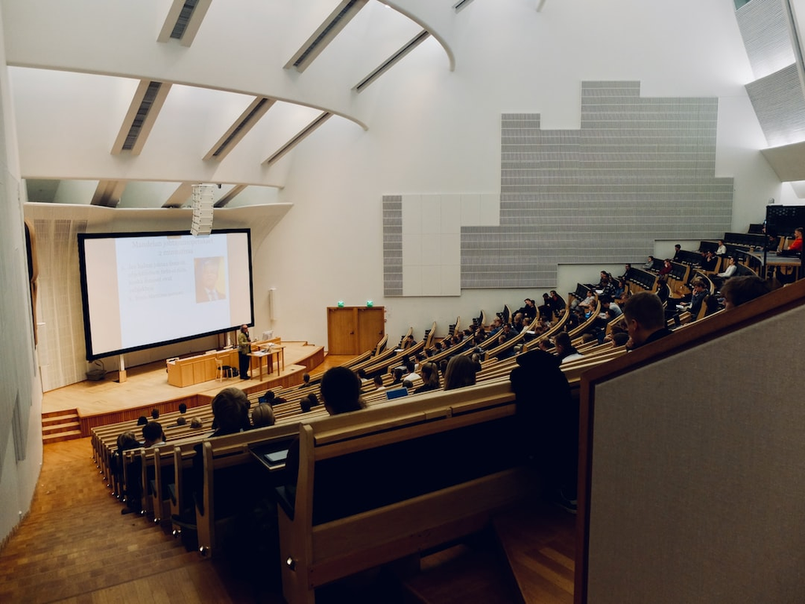

[^2]: Credit: [`@domlafou`](https://unsplash.com/photos/YRMWVcdyhmI)

## Alerts & cross-refs

To emphasize specific words or text, you can:

- Use the default `.alert` class, e.g. important note.
- Use the `.fg` class for custom colour, e.g. important note.
- Use the `.bg` class for custom background, e.g. important note.
- I’ve also added some convenient CSS classes, e.g. `.ubdblue`, `.ubdteal`, `.ubdyellow`, `.ubdred`.

## Citations

Citations follow the standard [Quarto format](https://quarto.org/docs/authoring/footnotes-and-citations.html#citations) and be sourced from BibLaTex, BibTeX, or CLS files. For example:

- Topic 1: Spatial Frictions (Fajgelbaum et al. 2018; Hsieh and Moretti 2019; Moretti 2011)
- Topic 2: Blah (Suárez Serrato and Zidar 2016)

Hover over the citations to get the full reference.

# Mathematics

## Using maths

Let $X$ be a simple random variable defined on $(\Omega,\mathcal F,\mathbb P)$ that takes on finitely many values $\{x_1,\dots,x_n\}$. The expectation of $X$, $\operatorname{E}(X)$, is the Lebesgue integral of $X$ with respect to $\mathbb P$,
$$\operatorname{E}(X) := \int X(\omega) \operatorname{d \mathbb P} = \sum_{i=1}^n x_i \operatorname{\mathbb P}(\omega \in A_i),$$
where $A_i=\{\omega\in\Omega \mid X(\omega)=x_i \}$.

$$\begin{gather*}
AaBbCcDdEeFfGgHhIiJjKkLlMmNnOoPpQqRrSsTtUuVv\\WwXxYyZz \\[0.5em]
1234567890 \\[0.5em]
\alpha
\beta
\Gamma \gamma
\Delta \delta
\epsilon \varepsilon
\zeta
\eta
\Theta \theta \vartheta
\iota
\kappa \varkappa
\Lambda \lambda
\mu
\nu
\Xi \xi
\Pi \pi \varpi
\rho
\Sigma \sigma
\tau
\Upsilon \upsilon
\Phi \phi \varphi
\chi
\Psi \psi
\Omega \omega \\[0.5em]
\prod \oint \bigoplus \bigotimes \bigcup \bigcap
\end{gather*}$$

## Theorems et al.

**Definition 1 (Prime numbers)** A prime number is a natural number greater than 1 that is not a product of two smaller natural numbers.

**Theorem 1 (Infinitude of primes)** There are infinite prime numbers.

*Proof*. To prove Theorem 1, we need to use Definition 1. Suppose that there exist only a finite number of primes, $p_1,\dots,p_n$, say. The number
$$N = 1+p_1\cdots p_n$$
is divisible by some prime $p$. But $p$ cannot be any of $p_1,\dots,p_n$, since the latter all leave remainder 1 on dividing $N$. This contradicts our assumption that $p_1,\dots,p_n$ is the complete list of primes.

See also https://quarto.org/docs/authoring/cross-references.html#theorems-and-proofs

## Theorems via callout blocks?

## Components

### Blocks

Quarto provides [dedicated environments](https://quarto.org/docs/authoring/cross-references.html#theorems-and-proofs) for theorems, lemmas, and so forth.

**Theorem 2 (Regression Specification)** The main specification is as follows:

$$y_{it} = X_{it} \beta + \mu_i + \varepsilon_{it}$$

## Blocks

But in presentation format, it’s arguably more effective just to use a [Callout Block](https://quarto.org/docs/authoring/callouts.html).

**Regression Specification**

The main specification is as follows:

$$y_{it} = X_{it} \beta + \mu_i + \varepsilon_{it}$$

## Components

### Multicolumn I: Text only

Here is a long sentence that will wrap onto the next line as it hits the column width, and continue this way until it stops.

Some other text in another column.

A second paragraph.

Multicolumn support is very flexible and we can continue with a single full span column in the same slide.

## Components

### Multicolumn II: Text and figures

[figure not shown]

- A point about the figure that is potentially important.
- Another point about the figure that is also potentially important.

Note that sub- and multi-panel figures are also natively supported by Quarto. See [here](https://quarto.org/docs/authoring/figures.html#subfigures).

## Components

### Multicolumn III: Code and output

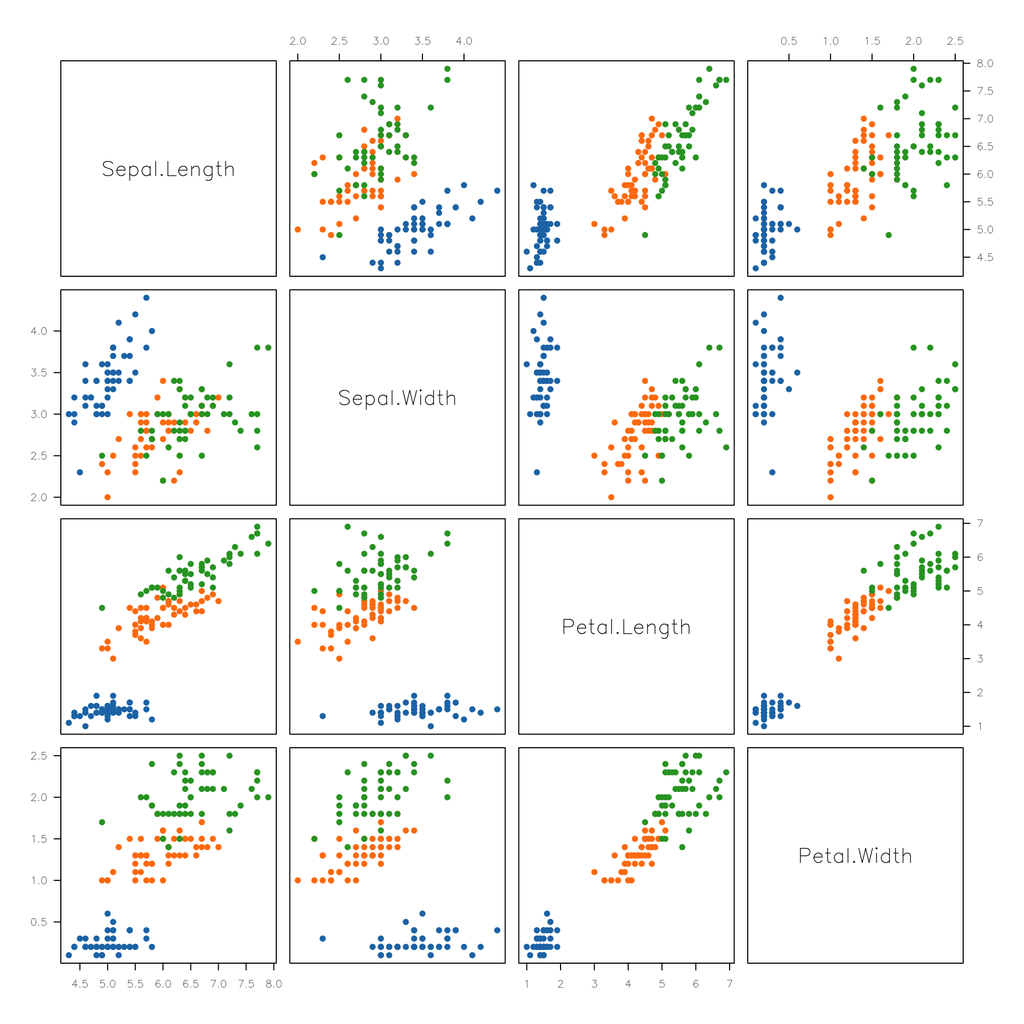

Figure 1: Pairwise scatterplot

```r
palette("Classic Tableau")

par(
  family = "HersheySans",
  las = 1, pch = 19, cex = 1.5
)

pairs(
  iris[,1:4],
  col=iris$Species
)
```

# Tables

## Tables

### Regression example

Quarto offers excellent [table support](https://quarto.org/docs/authoring/tables.html), with further customization via user libraries. Let’s illustrate with a regression example:

```r
library(fixest)

mods = feols(
  rating ~ complaints + privileges + learning + csw0(raises + critical) + advance,
  data = attitude
)

dict = c("rating"     = "Overall Rating",
         "complaints" = "Handling of Complaints",
         "privileges" = "No Special Priviledges",
         "learning"   = "Opportunity to Learn",
         "raises"     = "Performance-Based Raises",
         "critical"   = "Too Critical",
         "advance"    = "Advancement")
```

## Regression table

### modelsummary

If you use `modelsummary` with this Quarto theme, we advise setting the `gt` backend for a cleaner aesthetic. More details [here](https://vincentarelbundock.github.io/modelsummary/articles/appearance.html).

```r
library(modelsummary)
options(modelsummary_factory_default = "gt")

modelsummary(
  setNames(mods, c("(1)", "(2)")),
  coef_map = dict, stars = TRUE,
  gof_omit = "Adj|IC|F|Log|RMSE"
  ) |>
  gt::tab_spanner(
    label = "Dependent variable: Overall Rating",
    columns = 2:3
  )
```

## Regression table

|  | Dependent variable: Overall Rating (1) | Dependent variable: Overall Rating (2) |
| --- | --- | --- |
| Handling of Complaints | 0.653*** | 0.613*** |
|  | (0.131) | (0.161) |
| No Special Priviledges | -0.077 | -0.073 |
|  | (0.131) | (0.136) |
| Opportunity to Learn | 0.324+ | 0.320+ |
|  | (0.157) | (0.169) |
| Performance-Based Raises |  | 0.082 |
|  |  | (0.221) |
| Too Critical |  | 0.038 |
|  |  | (0.147) |
| Advancement | -0.172 | -0.217 |
|  | (0.149) | (0.178) |
| Num.Obs. | 30 | 30 |
| R2 | 0.729 | 0.733 |
| Std.Errors | IID | IID |

+ p < 0.1, * p < 0.05, ** p < 0.01, *** p < 0.001

## Regression table

### etable

`fixest`’s powerful native tabling functions were designed for LaTeX output. But we can use the `markdown = TRUE` option to make them work with this theme too. (Details [here](https://lrberge.github.io/fixest/articles/etable_new_features.html).) Quick notes:

- Install the `tinytex` & `pdftools` packages first.
- Set the R chunk option `output: asis`.

````markdown
```{r}
#| output: asis

setFixest_etable(markdown = TRUE, drop = "Constant")
setFixest_dict(dict)

etable(mods, highlight = .("se" = "complaints"))
```
````

[output not shown]

## Regression table

# Figures

## Figure

[figure not shown]

## Figure

### Full-size Figures

You can use the `{.background-image}` container environment to completely fill the slide background with an image.

Ideally, your figure will be the same aspect ratio as the screen that you’re presenting on.

- This can be a bit tricky because of the dynamic nature of reveal.js / HTML. But it’s probably something close to 16:9.
- Aspect ratio can also matter for a regular full-frame images (previous slide).

## Interactive plots

# Summary

## Summary

### A minimal and elegant presentation theme

The Quarto reveal.js clean theme aims to be a minimal and elegant presention theme.

We have highlighted some theme-specific components. But all of the regular reveal.js functionality is supported (chalkboard, etc.)

Install the theme:

```bash
quarto install extension grantmcdermott/quarto-revealjs-clean
```

Use these demo slides as a template:

```bash
quarto use template grantmcdermott/quarto-revealjs-clean-demo
```

## Hello, There

This presentation will show you examples of what you can do with Quarto and [Reveal.js](https://revealjs.com), including:

- Presenting code and LaTeX equations
- Including computations in slide output
- Image, video, and iframe backgrounds
- Fancy transitions and animations
- Printing to PDF

…and much more

## Pretty Code

- Over 20 syntax highlighting themes available
- Default theme optimized for accessibility

```r
# Define a server for the Shiny app
function(input, output) {

  # Fill in the spot we created for a plot
  output$phonePlot <- renderPlot({
    # Render a barplot
  })
}
```

Learn more: [Syntax Highlighting](https://quarto.org/docs/output-formats/html-code.html#highlighting)

## Code Animations

- Over 20 syntax highlighting themes available
- Default theme optimized for accessibility

```r
# Define a server for the Shiny app
function(input, output) {

  # Fill in the spot we created for a plot
  output$phonePlot <- renderPlot({
    # Render a barplot
    barplot(WorldPhones[,input$region]*1000,
            main=input$region,
            ylab="Number of Telephones",
            xlab="Year")
  })
}
```

Learn more: [Code Animations](https://quarto.org/docs/presentations/revealjs/advanced.html#code-animations)

## Line Highlighting

- Highlight specific lines for emphasis
- Incrementally highlight additional lines

```python
import numpy as np
import matplotlib.pyplot as plt

r = np.arange(0, 2, 0.01)
theta = 2 * np.pi * r
fig, ax = plt.subplots(subplot_kw={'projection': 'polar'})
ax.plot(theta, r)
ax.set_rticks([0.5, 1, 1.5, 2])
ax.grid(True)
plt.show()
```

Learn more: [Line Highlighting](https://quarto.org/docs/presentations/revealjs/#line-highlighting)

## Executable Code

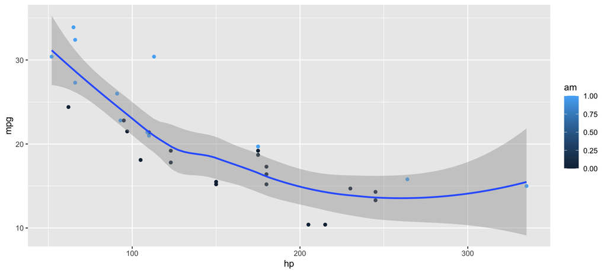

```r
library(ggplot2)
ggplot(mtcars, aes(hp, mpg, color = am)) +
  geom_point() +
  geom_smooth(formula = y ~ x, method = "loess")
```

Learn more: [Executable Code](https://quarto.org/docs/presentations/revealjs/#executable-code)

## LaTeX Equations

[MathJax](https://www.mathjax.org/) rendering of equations to HTML

```latex
\begin{gather*}
a_1=b_1+c_1\\
a_2=b_2+c_2-d_2+e_2
\end{gather*}

\begin{align}
a_{11}& =b_{11}&
  a_{12}& =b_{12}\\
a_{21}& =b_{21}&
  a_{22}& =b_{22}+c_{22}
\end{align}
```

$$\begin{gather*}
a_1=b_1+c_1\\
a_2=b_2+c_2-d_2+e_2
\end{gather*}$$
$$\begin{align}
a_{11}& =b_{11}&
a_{12}& =b_{12}\\
a_{21}& =b_{21}&
a_{22}& =b_{22}+c_{22}
\end{align}$$

Learn more: [LaTeX Equations](https://quarto.org/docs/authoring/markdown-basics.html#equations)

## Column Layout

Arrange content into columns of varying widths:

#### Motor Trend Car Road Tests

The data was extracted from the 1974 Motor Trend US magazine, and comprises fuel consumption and 10 aspects of automobile design and performance for 32 automobiles.

|  | mpg | cyl | disp | hp | wt |
| --- | --- | --- | --- | --- | --- |
| Mazda RX4 | 21.0 | 6 | 160 | 110 | 2.620 |
| Mazda RX4 Wag | 21.0 | 6 | 160 | 110 | 2.875 |
| Datsun 710 | 22.8 | 4 | 108 | 93 | 2.320 |
| Hornet 4 Drive | 21.4 | 6 | 258 | 110 | 3.215 |
| Hornet Sportabout | 18.7 | 8 | 360 | 175 | 3.440 |
| Valiant | 18.1 | 6 | 225 | 105 | 3.460 |

Learn more: [Multiple Columns](https://quarto.org/docs/presentations/revealjs/#multiple-columns)

## Incremental Lists

Lists can optionally be displayed incrementally:

- First item
- Second item
- Third item

Insert pauses to make other types of content display incrementally.

Learn more: [Incremental Lists](https://quarto.org/docs/presentations/revealjs/#incremental-lists)

## Fragments

Incremental text display and animation with fragments:

Fade in

Slide up while fading in

Slide left while fading in

Fade in then semi out

Strike

Highlight red

Learn more: [Fragments](https://quarto.org/docs/presentations/revealjs/advanced.html#fragments)

## Slide Backgrounds

Set the `background` attribute on a slide to change the background color (all CSS color formats are supported).

Different background transitions are available via the `background-transition` option.

Learn more: [Slide Backgrounds](https://quarto.org/docs/presentations/revealjs/#color-backgrounds)

## Media Backgrounds

You can also use the following as a slide background:

- An image: `background-image`
- A video: `background-video`
- An iframe: `background-iframe`

Learn more: [Media Backgrounds](https://quarto.org/docs/presentations/revealjs/#image-backgrounds)

## Absolute Position

Position images or other elements at precise locations

[figure not shown]

Learn more: [Absolute Position](https://quarto.org/docs/presentations/revealjs/advanced.html#absolute-position)

## Auto-Animate

Automatically animate matching elements across slides with Auto-Animate.

Learn more: [Auto-Animate](https://quarto.org/docs/presentations/revealjs/advanced.html#auto-animate)

## Auto-Animate

Automatically animate matching elements across slides with Auto-Animate.

Learn more: [Auto-Animate](https://quarto.org/docs/presentations/revealjs/advanced.html#auto-animate)

## Slide Transitions

The next few slides will transition using the `slide` transition

| Transition | Description |
| --- | --- |
| `none` | No transition (default, switch instantly) |
| `fade` | Cross fade |
| `slide` | Slide horizontally |
| `convex` | Slide at a convex angle |
| `concave` | Slide at a concave angle |
| `zoom` | Scale the incoming slide so it grows in from the center of the screen. |

Learn more: [Slide Transitions](https://quarto.org/docs/presentations/revealjs/advanced.html#slide-transitions)

## Tabsets

- Plot
- Data

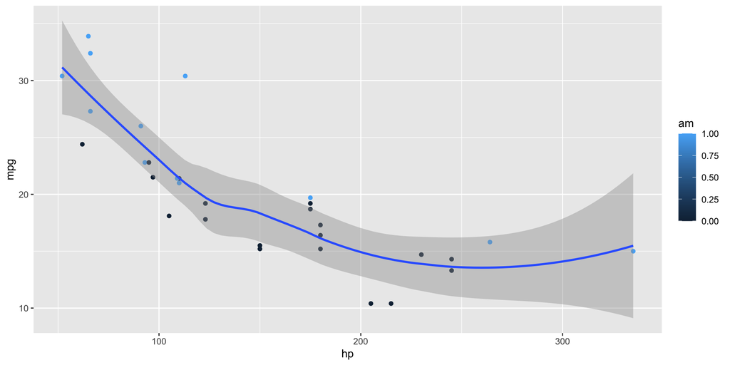

|  | mpg | cyl | disp | hp | drat | wt | qsec | vs | am | gear | carb |
| --- | --- | --- | --- | --- | --- | --- | --- | --- | --- | --- | --- |
| Mazda RX4 | 21.0 | 6 | 160.0 | 110 | 3.90 | 2.620 | 16.46 | 0 | 1 | 4 | 4 |
| Mazda RX4 Wag | 21.0 | 6 | 160.0 | 110 | 3.90 | 2.875 | 17.02 | 0 | 1 | 4 | 4 |
| Datsun 710 | 22.8 | 4 | 108.0 | 93 | 3.85 | 2.320 | 18.61 | 1 | 1 | 4 | 1 |
| Hornet 4 Drive | 21.4 | 6 | 258.0 | 110 | 3.08 | 3.215 | 19.44 | 1 | 0 | 3 | 1 |
| Hornet Sportabout | 18.7 | 8 | 360.0 | 175 | 3.15 | 3.440 | 17.02 | 0 | 0 | 3 | 2 |
| Valiant | 18.1 | 6 | 225.0 | 105 | 2.76 | 3.460 | 20.22 | 1 | 0 | 3 | 1 |
| Duster 360 | 14.3 | 8 | 360.0 | 245 | 3.21 | 3.570 | 15.84 | 0 | 0 | 3 | 4 |
| Merc 240D | 24.4 | 4 | 146.7 | 62 | 3.69 | 3.190 | 20.00 | 1 | 0 | 4 | 2 |
| Merc 230 | 22.8 | 4 | 140.8 | 95 | 3.92 | 3.150 | 22.90 | 1 | 0 | 4 | 2 |
| Merc 280 | 19.2 | 6 | 167.6 | 123 | 3.92 | 3.440 | 18.30 | 1 | 0 | 4 | 4 |
| Merc 280C | 17.8 | 6 | 167.6 | 123 | 3.92 | 3.440 | 18.90 | 1 | 0 | 4 | 4 |
| Merc 450SE | 16.4 | 8 | 275.8 | 180 | 3.07 | 4.070 | 17.40 | 0 | 0 | 3 | 3 |
| Merc 450SL | 17.3 | 8 | 275.8 | 180 | 3.07 | 3.730 | 17.60 | 0 | 0 | 3 | 3 |
| Merc 450SLC | 15.2 | 8 | 275.8 | 180 | 3.07 | 3.780 | 18.00 | 0 | 0 | 3 | 3 |
| Cadillac Fleetwood | 10.4 | 8 | 472.0 | 205 | 2.93 | 5.250 | 17.98 | 0 | 0 | 3 | 4 |
| Lincoln Continental | 10.4 | 8 | 460.0 | 215 | 3.00 | 5.424 | 17.82 | 0 | 0 | 3 | 4 |
| Chrysler Imperial | 14.7 | 8 | 440.0 | 230 | 3.23 | 5.345 | 17.42 | 0 | 0 | 3 | 4 |
| Fiat 128 | 32.4 | 4 | 78.7 | 66 | 4.08 | 2.200 | 19.47 | 1 | 1 | 4 | 1 |
| Honda Civic | 30.4 | 4 | 75.7 | 52 | 4.93 | 1.615 | 18.52 | 1 | 1 | 4 | 2 |
| Toyota Corolla | 33.9 | 4 | 71.1 | 65 | 4.22 | 1.835 | 19.90 | 1 | 1 | 4 | 1 |
| Toyota Corona | 21.5 | 4 | 120.1 | 97 | 3.70 | 2.465 | 20.01 | 1 | 0 | 3 | 1 |
| Dodge Challenger | 15.5 | 8 | 318.0 | 150 | 2.76 | 3.520 | 16.87 | 0 | 0 | 3 | 2 |
| AMC Javelin | 15.2 | 8 | 304.0 | 150 | 3.15 | 3.435 | 17.30 | 0 | 0 | 3 | 2 |
| Camaro Z28 | 13.3 | 8 | 350.0 | 245 | 3.73 | 3.840 | 15.41 | 0 | 0 | 3 | 4 |
| Pontiac Firebird | 19.2 | 8 | 400.0 | 175 | 3.08 | 3.845 | 17.05 | 0 | 0 | 3 | 2 |
| Fiat X1-9 | 27.3 | 4 | 79.0 | 66 | 4.08 | 1.935 | 18.90 | 1 | 1 | 4 | 1 |
| Porsche 914-2 | 26.0 | 4 | 120.3 | 91 | 4.43 | 2.140 | 16.70 | 0 | 1 | 5 | 2 |
| Lotus Europa | 30.4 | 4 | 95.1 | 113 | 3.77 | 1.513 | 16.90 | 1 | 1 | 5 | 2 |
| Ford Pantera L | 15.8 | 8 | 351.0 | 264 | 4.22 | 3.170 | 14.50 | 0 | 1 | 5 | 4 |
| Ferrari Dino | 19.7 | 6 | 145.0 | 175 | 3.62 | 2.770 | 15.50 | 0 | 1 | 5 | 6 |
| Maserati Bora | 15.0 | 8 | 301.0 | 335 | 3.54 | 3.570 | 14.60 | 0 | 1 | 5 | 8 |
| Volvo 142E | 21.4 | 4 | 121.0 | 109 | 4.11 | 2.780 | 18.60 | 1 | 1 | 4 | 2 |

Learn more: [Tabsets](https://quarto.org/docs/presentations/revealjs/#tabsets)

## Interactive Slides

## Preview Links

Navigate to hyperlinks without disrupting the flow of your presentation.

Use the `preview-links` option to open links in an iframe on top of your slides. Try clicking the link below for a demonstration:

[Matplotlib: Visualization with Python](https://matplotlib.org/)

Learn more: [Preview Links](https://quarto.org/docs/presentations/revealjs/presenting.html#preview-links)

## Themes

10 Built-in Themes (or [create your own](https://quarto.org/docs/presentations/revealjs/themes.html#creating-themes))

[figure not shown]

Learn more: [Themes](https://quarto.org/docs/presentations/revealjs/themes.html)

## Easy Navigation

Quickly jump to other parts of your presentation

Toggle the slide menu with the menu button (bottom left of slide) to go to other slides and access presentation tools.

You can also press `m` to toggle the menu open and closed.

Learn more: [Navigation](https://quarto.org/docs/presentations/revealjs/presenting.html#navigation-menu)

## Chalkboard

Free form drawing and slide annotations

Use the chalkboard button at the bottom left of the slide to toggle the chalkboard.

Use the notes canvas button at the bottom left of the slide to toggle drawing on top of the current slide.

You can also press `b` to toggle the chalkboard or `c` to toggle the notes canvas.

Learn more: [Chalkboard](https://quarto.org/docs/presentations/revealjs/presenting.html#chalkboard)

## Point of View

Press `o` to toggle overview mode:

[figure not shown]

Hold down the `Alt` key (or `Ctrl` in Linux) and click on any element to zoom towards it—try it now on this slide.

Learn more: [Overview Mode](https://quarto.org/docs/presentations/revealjs/presenting.html#overview-mode), [Slide Zoom](https://quarto.org/docs/presentations/revealjs/presenting.html#slide-zoom)

## Speaker View

Press `s` (or use the presentation menu) to open speaker view

[figure not shown]

Learn more: [Speaker View](https://quarto.org/docs/presentations/revealjs/presenting.html#speaker-view)

## Authoring Tools

Live side-by-side preview for any notebook or text editor including Jupyter and VS Code

[figure not shown]

Learn more: [Jupyter](https://quarto.org/docs/tools/jupyter-lab.html), [VS Code](https://quarto.org/docs/tools/vscode.html), [Text Editors](https://quarto.org/docs/tools/text-editors.html)

## Authoring Tools

RStudio includes an integrated presentation preview pane

[figure not shown]

Learn more: [RStudio](https://quarto.org/docs/tools/rstudio.html)

## And More…

- [Touch](https://quarto.org/docs/presentations/revealjs/advanced.html#touch-navigation) optimized (presentations look great on mobile, swipe to navigate slides)
- [Footer & Logo](https://quarto.org/docs/presentations/revealjs/#footer-logo) (optionally specify custom footer per-slide)
- [Auto-Slide](https://quarto.org/docs/presentations/revealjs/presenting.html#auto-slide) (step through slides automatically, without any user input)
- [Multiplex](https://quarto.org/docs/presentations/revealjs/presenting.html#multiplex) (allows your audience to follow the slides of the presentation you are controlling on their own phone, tablet or laptop).

Learn more: [Quarto Presentations](https://quarto.org/docs/presentations/revealjs/)

## References

Fajgelbaum, Pablo D, Eduardo Morales, Juan Carlos Suarez Serrato, and Owen Zidar. 2018. “State Taxes and Spatial Misallocation,” 90.

Hsieh, Chang-Tai, and Enrico Moretti. 2019. “Housing Constraints and Spatial Misallocation.” *American Economic Journal: Macroeconomics* 11 (2): 39.

Moretti, Enrico. 2011. “Local Labor Markets.” In *Handbook of Labor Economics*. Vol. 4. Elsevier.

Suárez Serrato, Juan Carlos, and Owen Zidar. 2016. “Who Benefits from State Corporate Tax Cuts? A Local Labor Markets Approach with Heterogeneous Firms.” *American Economic Review* 106 (9).

## Appendix

Back to main

[figure not shown]